# SMI Data File ReadMe v1

Nanostring Technologies

10/4/2021

# Transcript File

Lung5_Rep2_tx_file.csv : 3.7 GB

| fov | cell_ID | x_global_px | y_global_px | x_local_px | y_local_px | z | target | CellComp |
| --- | --- | --- | --- | --- | --- | --- | --- | --- |
| 1 | 135 | 12059.69 | 162613.4 | 4709.695 | 3441.217 | 2 | HLA-A | Cytoplasm |
| 1 | 135 | 12065.03 | 162624.8 | 4715.033 | 3452.533 | 2 | MXRA8 | Cytoplasm |
| 1 | 135 | 12065.57 | 162626.4 | 4715.575 | 3454.138 | 2 | MT1X | Cytoplasm |
| 1 | 135 | 12057.36 | 162633.1 | 4707.362 | 3460.925 | 2 | FZD6 | Cytoplasm |
| 1 | 135 | 12055.38 | 162632.0 | 4705.375 | 3459.750 | 2 | IGFBP7 | Cytoplasm |
| 1 | 135 | 12056.98 | 162610.1 | 4706.980 | 3437.860 | 2 | RPL22 | Cytoplasm |
| 1 | 135 | 12066.88 | 162623.7 | 4716.880 | 3451.440 | 2 | KRT13 | Cytoplasm |
| 1 | 135 | 12063.75 | 162613.6 | 4713.750 | 3441.375 | 2 | IGKC | Cytoplasm |
| 1 | 135 | 12056.57 | 162630.4 | 4706.574 | 3458.179 | 2 | GPX3 | Cytoplasm |
| 1 | 135 | 12059.90 | 162632.5 | 4709.900 | 3460.275 | 2 | LGALS3BP | Cytoplasm |

- **Column descriptions:**
  - **fov**
    - The Field Of View (FOV) the transcript is in. All FOVs from the sample are contained within this transcript file.
  - **cell_ID**
    - Unique identifier for a single cell within a given FOV. To make a unique identifier for a cell within the whole sample use both the “fov” and “cell_ID” columns. Transcripts not assigned to cells have a value of 0.
  - **x_global_px**
    - See “x_local_px” description. The global positions describes the relative position of this transcript within the large sample reference frame.
  - **y_global_px**
    - Same as “x_global_px” but for the y dimension
  - **x_local_px**
    - The x position of this transcipt within the FOV, measured in pixels. To convert to microns multiply the pixel value by 0.18 um per pixel.
  - **y_local_px**
    - Same as “x_local_px” but for the y dimension
  - **z**
    - The Z-slice image number. This has an arbitrary unit.
  - **target**
    - The gene detected. HUGO gene symbols are used.
  - **CellComp** +The subcellular compartment (Nuclear, Membrane, or Cytoplasmic. “0” denotes Extracellular) in which the transcript was detected as determined by cell segmentation algorithm.

# Cell Expression File

Lung5_Rep2_exprMat_file.csv : 210.4 MB

|  | fov | cell_ID | AATK | ABL1 | ABL2 | ACE | ACE2 | ACKR1 | ACKR3 | ACKR4 | ACTA2 | ACTG2 | ACVR1 | ACVR1B | ACVR2A | ACVRL1 | ADGRA2 | ADGRA3 | ADGRB2 | ADGRB3 | ADGRD1 | ADGRE1 | ADGRE2 | ADGRE5 | ADGRF1 | ADGRF3 | ADGRF4 | ADGRF5 | ADGRG1 | … |
| --- | --- | --- | --- | --- | --- | --- | --- | --- | --- | --- | --- | --- | --- | --- | --- | --- | --- | --- | --- | --- | --- | --- | --- | --- | --- | --- | --- | --- | --- | --- |
| 2 | 1 | 998 | 0 | 0 | 0 | 0 | 1 | 0 | 0 | 0 | 1 | 0 | 0 | 0 | 0 | 0 | 0 | 0 | 1 | 0 | 0 | 0 | 1 | 0 | 0 | 0 | 0 | 2 | 0 | … |
| 3 | 1 | 999 | 0 | 0 | 0 | 0 | 0 | 0 | 0 | 0 | 0 | 0 | 0 | 0 | 0 | 0 | 0 | 0 | 0 | 0 | 0 | 0 | 0 | 0 | 0 | 0 | 0 | 0 | 0 | … |
| 4 | 1 | 1000 | 0 | 0 | 0 | 0 | 0 | 0 | 0 | 0 | 0 | 0 | 0 | 0 | 0 | 0 | 0 | 0 | 0 | 0 | 0 | 0 | 0 | 0 | 0 | 0 | 0 | 0 | 0 | … |
| 5 | 1 | 1001 | 0 | 0 | 0 | 0 | 0 | 0 | 0 | 0 | 0 | 0 | 0 | 0 | 0 | 0 | 0 | 0 | 0 | 0 | 0 | 0 | 1 | 0 | 0 | 0 | 0 | 1 | 0 | … |
| 6 | 1 | 1002 | 0 | 0 | 0 | 0 | 0 | 0 | 0 | 0 | 0 | 0 | 2 | 0 | 0 | 0 | 0 | 0 | 0 | 0 | 0 | 0 | 0 | 1 | 0 | 0 | 0 | 0 | 0 | … |
| 7 | 1 | 1003 | 0 | 0 | 0 | 0 | 0 | 0 | 0 | 1 | 0 | 0 | 0 | 0 | 0 | 0 | 1 | 0 | 0 | 0 | 0 | 0 | 0 | 0 | 0 | 0 | 0 | 0 | 0 | … |
| 8 | 1 | 1004 | 0 | 0 | 0 | 0 | 0 | 0 | 0 | 0 | 0 | 0 | 0 | 0 | 0 | 0 | 0 | 0 | 0 | 0 | 0 | 0 | 0 | 0 | 0 | 0 | 0 | 1 | 0 | … |
| 9 | 1 | 1005 | 0 | 0 | 0 | 0 | 0 | 0 | 0 | 0 | 0 | 0 | 0 | 0 | 0 | 0 | 0 | 0 | 0 | 0 | 0 | 0 | 0 | 0 | 0 | 0 | 0 | 0 | 0 | … |
| 10 | 1 | 1006 | 0 | 0 | 0 | 0 | 0 | 0 | 0 | 0 | 0 | 0 | 0 | 1 | 0 | 0 | 0 | 0 | 0 | 0 | 0 | 0 | 0 | 0 | 0 | 0 | 0 | 0 | 0 | … |
| 11 | 1 | 1007 | 0 | 0 | 0 | 0 | 0 | 0 | 0 | 0 | 0 | 0 | 0 | 0 | 0 | 0 | 0 | 0 | 2 | 0 | 2 | 0 | 0 | 0 | 0 | 0 | 2 | 0 | 0 | … |

- **Column descriptions:**
  - **fov**
    - The Field Of View (FOV) the transcript is in. All FOVs from the sample are contained within this Cell Expression file.
  - **cell_ID**
    - Unique identifier for a single cell within a given FOV. To make a unique identifier for a cell within the whole sample use both the “fov” and “cell_ID” columns. All transcripts not assigned to a cell are show with a “cell_ID” value of 0.
  - **Gene expression target (AATK, ABL1, …, etc)**
    - The number of transcripts observed for a given gene target for a given cell.
  - **Negative probes (i.e. NegPrb##)**
    - Negative probes, which do not match any sequence within the transcriptome or genome, are included. These can be used to assess background levels.

# Cell Metadata File

Lung5_Rep2_metadata_file.csv : 12.0 MB

| fov | cell_ID | Area | AspectRatio | CenterX_local_px | CenterY_local_px | CenterX_global_px | CenterY_global_px | Width | Height | Mean.MembraneStain | Max.MembraneStain | Mean.PanCK | Max.PanCK | Mean.CD45 | Max.CD45 | Mean.CD3 | Max.CD3 | Mean.DAPI | Max.DAPI |
| --- | --- | --- | --- | --- | --- | --- | --- | --- | --- | --- | --- | --- | --- | --- | --- | --- | --- | --- | --- |
| 1 | 1 | 2142 | 1.48 | 806 | 3628 | 8156 | 162800.2 | 59 | 40 | 1075 | 1842 | 22954 | 49711 | 76 | 385 | 0 | 78 | 1784 | 11384 |
| 1 | 2 | 2236 | 2.08 | 980 | 3630 | 8330 | 162802.2 | 75 | 36 | 1232 | 4073 | 23035 | 65311 | 90 | 10963 | 0 | 248 | 2751 | 17658 |
| 1 | 3 | 4845 | 1.15 | 1637 | 3607 | 8987 | 162779.2 | 94 | 82 | 4367 | 11890 | 1593 | 26734 | 225 | 1329 | 5 | 283 | 8988 | 35448 |
| 1 | 4 | 2915 | 1.00 | 1694 | 3619 | 9044 | 162791.2 | 59 | 59 | 6017 | 13814 | 12387 | 50409 | 54 | 623 | 0 | 96 | 69 | 3837 |
| 1 | 5 | 8634 | 1.02 | 1869 | 3596 | 9219 | 162768.2 | 106 | 104 | 3945 | 13832 | 10624 | 47795 | 42 | 10543 | 0 | 85 | 227 | 6058 |
| 1 | 6 | 2248 | 0.66 | 2208 | 3617 | 9558 | 162789.2 | 41 | 62 | 1918 | 5078 | 7462 | 25661 | 31 | 268 | 0 | 0 | 1983 | 11738 |
| 1 | 7 | 5147 | 1.09 | 2270 | 3610 | 9620 | 162782.2 | 84 | 77 | 3210 | 10551 | 715 | 11854 | 20 | 264 | 0 | 16 | 5498 | 29958 |
| 1 | 8 | 3798 | 2.17 | 2561 | 3622 | 9911 | 162794.2 | 115 | 53 | 2732 | 8958 | 6951 | 43479 | 813 | 45043 | 0 | 148 | 2218 | 21364 |
| 1 | 9 | 3790 | 3.16 | 2665 | 3630 | 10015 | 162802.2 | 117 | 37 | 5468 | 13925 | 849 | 6014 | 358 | 7788 | 7 | 386 | 8381 | 35995 |
| 1 | 10 | 3901 | 1.35 | 3402 | 3620 | 10752 | 162792.2 | 77 | 57 | 4676 | 10663 | 270 | 666 | 34 | 501 | 0 | 100 | 12053 | 36001 |

- **Column descriptions:**
  - **fov**
    - The Field Of View (FOV) the transcript is in. All FOVs from the sample are contained within this Cell Metadata file.
  - **cell_ID**
    - Unique identifier for a single cell within a given FOV. To make a unique identifier for a cell within the whole sample use both the “fov” and “cell_ID” columns.
  - **Area**
    - Number of pixels assigned to a given cell.
  - **Aspect Ratio**
    - width divided by height.
  - **CenterX_global_px**
    - See “CenterX_local_px” description. The global positions describes the relative position of this transcript within the large sample reference frame.
  - **CenterY_global_px**
    - Same as “CenterX_global_px” but for the y dimension
  - **CenterX_local_px**
    - The x position of this transcipt within the FOV, measured in pixels. The pixel edge length is 180nm. Thus, to convert to microns multiply the pixel value by 0.18 um per pixel.
  - **CenterY_local_px**
    - Same as “CenterX_local_px” but for the y dimension
  - **Width**
    - Cell’s maximum length in x dimension (pixels)
  - **Height**
    - Cell’s maximum length in y dimension (pixels)
  - **Mean.MembraneStain**
    - Mean fluorescence intensity within a given cell for the channel detecting the membrane stain.
  - **Max.MembraneStain**
    - Maximum fluorescence intensity within a given cell for the channel detecting the membrane stain.
  - **Mean.PanCK**
    - Mean fluorescence intensity within a given cell for the Green Channel.
    - As the morphology markers are customizable this column will change to match the requested markers in each experiment.
  - **Max.PanCK**
    - Maximum fluorescence intensity within a given cell for the Green Channel.
    - As the morphology markers are customizable this column will change to match the requested markers in each experiment.
  - **Mean.CD45**
    - Mean fluorescence intensity within a given cell for the Yellow Channel.
    - As the morphology markers are customizable this column will change to match the requested markers in each experiment.
  - **Max.CD45**
    - Maximum fluorescence intensity within a given cell for the Yellow Channel.
    - As the morphology markers are customizable this column will change to match the requested markers in each experiment.
  - **Mean.CD3**
    - Mean fluorescence intensity within a given cell for the Red Channel.
    - As the morphology markers are customizable this column will change to match the requested markers in each experiment.
  - **Max.CD3**
    - Maximum fluorescence intensity within a given cell for the Red Channel.
    - As the morphology markers are customizable this column will change to match the requested markers in each experiment.
  - **Mean.DAPI**
    - Mean fluorescence intensity within a given cell for the DAPI Channel.
  - **Max.DAPI**
    - Maximum fluorescence intensity within a given cell for the DAPI Channel.

# FOV Positions File

##### This file is used to reference each FOV within the global structure of the sample.

Lung5_Rep2_fov_positions_file.csv : 1.1 kB

| fov | x_global_px | y_global_px |
| --- | --- | --- |
| 1 | 7350.00 | 159172.2 |
| 2 | 12822.22 | 159172.2 |
| 3 | 18294.44 | 159172.2 |
| 4 | 23766.67 | 159172.2 |
| 5 | 29238.89 | 159172.2 |
| 6 | 7350.00 | 162822.2 |
| 7 | 12822.22 | 162822.2 |
| 8 | 18294.44 | 162822.2 |
| 9 | 23766.67 | 162822.2 |
| 10 | 29238.89 | 162822.2 |

- **Column descriptions:**
  - **fov**
    - The Field Of View (FOV) number.
  - **x_global_px**
    - The relative x position of this the FOV, measured in pixels. To convert to microns multiply the pixel value by 0.18 um per pixel. All FOVs are the same dimension, 5472 x 3648 pixels.
  - **y_global_px**
    - See “x_global_px” description, but in for the y dimension.

# CellComposite Images

##### Each FOV has a CellComposite image that displays the ImmunoFluorescence intesity from the IHC markers selected for the SMI experiment.

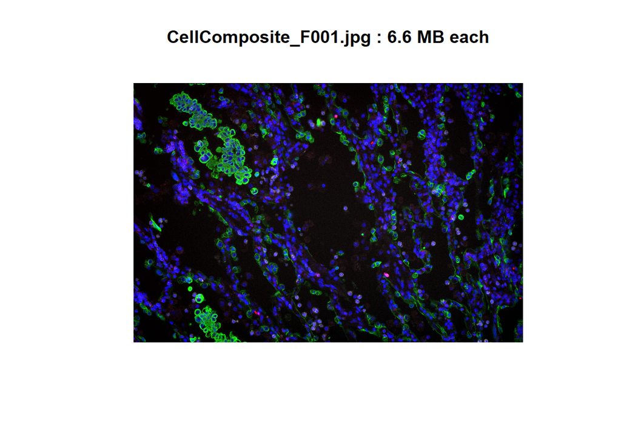

# CellOverlay Images

##### Each FOV has a CellOverlay image that displays the cell boundries determined during cell segmentation, shown as cyan lines.

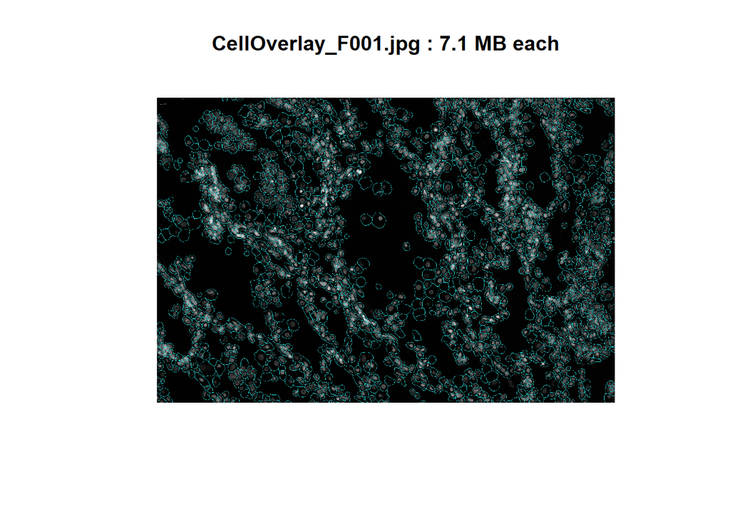

# CellLabels Images

##### Each FOV has a CellLabels image that displays the cell definitions determined during cell segmentation. Each cell identified is given a unique number (cell_ID) and all pixels determined to be within that cell have an intensity value matching that number. These cell_ID values are shared in the transcript, Cell Expression, and Cell Metadata files. A pixel not assigned to a cell has a “0” value.

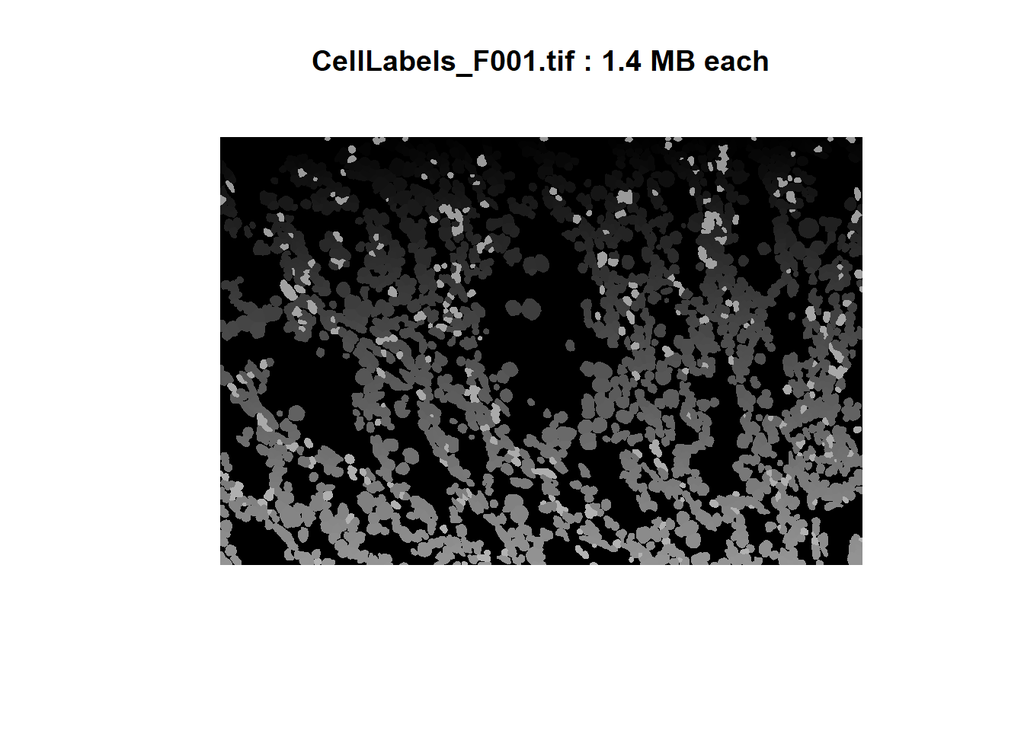

# CompartmentLabels Images

##### Each FOV has a CompartmentLabels image that displays the subcellular compartment definitions determined during cell segmentation. Each compartment type is given a unique number and all pixels determined to be within that compartment type have an intensity value matching that number.

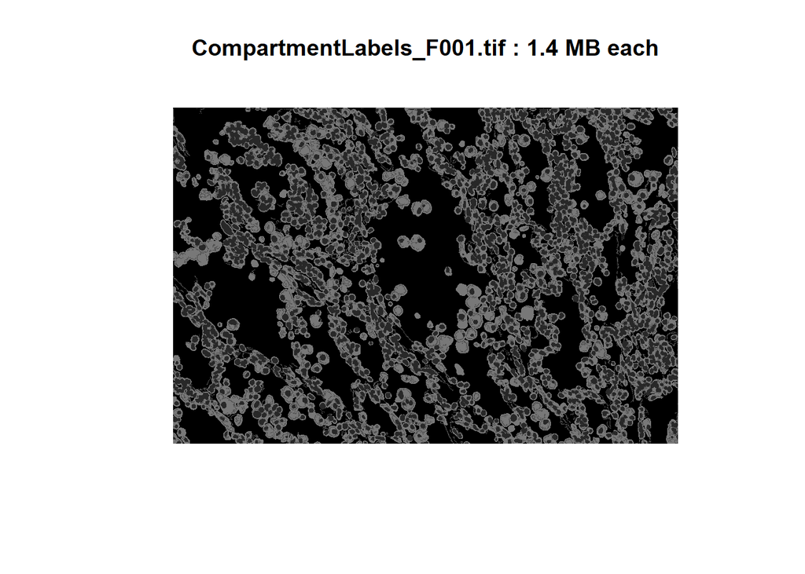

- **Compartment types**
  0. **Extracellular**
  1. **Nuclear**
  2. **Membrane**
  3. **Cytoplasmic**

# Raw Morphology Images

##### The raw TIF image files for each FOV (i.e. “FOV###” in file name). All Z-stacks are included (i.e. “Z###” in file name). These are used for cell segmentation and to produce the cellComposite jPEG images. Each image is ~195Mb, 8 images per FOV.

- **Channels**
  1. Membrane stain
  2. PanCK
  3. CD45
  4. CD3
  5. DAPI

# Processed Giotto object (All Slides)

##### For ease of sharing and analysis the data from all slides has been loaded into a single Giotto object, from the Giotto toolbox for integrative analysis of spatial expression data. The Giotto package can be found here (https://github.com/RubD/Giotto). To use this object please use the “suite” branch of the Giotto package, specifically commit 0c8c2866e881b1c6b35ddc97c24dcb58b555c375 which was used for this analysis.

- **Giotto publication**
  - Dries, R., Zhu, Q. et al. Giotto: a toolbox for integrative analysis and visualization of spatial expression data. Genome Biol. 2021 Mar 8;22(1):78.
  - https://genomebiology.biomedcentral.com/articles/10.1186/s13059-021-02286-2